# Klamath Basin Salmon Spawning

Badhia Yunes Katz - FlowWest

May 13, 2026

# About This Document

This document records **where and when salmon spawn in the Klamath River basin** using only the sources listed in the Source Inventory.

# Basin Overview

## Tributary locations

River km values from **Perry et al. (2019), p. 5**.

Tributary locations. Source: Perry et al. (2019) [PERRY-2019], p. 5.

| Tributary | River km | State | Video data in hand |
| --- | --- | --- | --- |
| Bogus Creek | 311.6 | CA | ✅ 2007–2022 |
| Shasta River | 289.6 | CA | ✅ 2006–2022 |
| Scott River | 232.8 | CA | ✅ 2008–2022 |
| Salmon River | 107.5 | CA | ⬜ Not yet collected |
| Trinity River | 70.6 | CA | ⬜ Not yet collected |

> **What the video counts measure:** Each row in the raw data is one fish observed on an underwater camera, classified by species and direction. Upstream (U) = fish entering the tributary to spawn. Annual upstream counts are a **passage index** — not a complete escapement estimate — but give precise run timing unavailable from any other source in hand.

## Species coverage

Upstream passage observations by tributary and species. Source: [CDFW-VIDEO]. Derived from cleaned CSV files.

| Tributary | Species | Years | Survey years | Total upstream obs |
| --- | --- | --- | --- | --- |
| Bogus Creek | Chinook | 2007 – 2022 | 16 | 82,487 |
| Bogus Creek | Coho | 2007 – 2022 | 16 | 2,677 |
| Bogus Creek | Steelhead | 2007 – 2022 | 16 | 6,404 |
| Scott River | Chinook | 2008 – 2022 | 15 | 33,395 |
| Scott River | Coho | 2008 – 2022 | 15 | 7,876 |
| Scott River | Steelhead | 2008 – 2022 | 15 | 2,897 |
| Shasta River | Chinook | 2006 – 2022 | 17 | 147,539 |
| Shasta River | Coho | 2006 – 2022 | 17 | 1,369 |
| Shasta River | Steelhead | 2006 – 2022 | 17 | 2,961 |

# Bogus Creek

**River km:** 311.6 | **State:** CA | **Monitoring:** CDFW Iron Gate Hatchery

Bogus Creek enters the Klamath 0.4 km below Iron Gate Dam and receives some of the earliest-arriving fall Chinook in the system. It is one of three upstream source populations in the Perry et al. (2019) S3 model.

> **Hatchery note:** Iron Gate Hatchery fish receive adipose fin clips. Adipose clip rates in carcass surveys range 0–47% across years — high-clip years indicate elevated hatchery contribution and should be interpreted cautiously for natural spawner abundance.

## Fall Chinook — run timing

Bogus Creek fall Chinook upstream passage. Source: [CDFW-VIDEO]. Peak week = calendar week with highest daily upstream count. Years with fewer than 20 upstream fish excluded.

| Year | Upstream count | First fish | Peak week | Last fish |
| --- | --- | --- | --- | --- |
| 2007 | 4,483 | Sep 25 | Oct 14 | Dec 04 |
| 2008 | 5,134 | Sep 08 | Oct 12 | Nov 20 |
| 2009 | 6,268 | Sep 08 | Oct 11 | Dec 13 |
| 2010 | 4,305 | Sep 07 | Oct 17 | Dec 11 |
| 2011 | 9,018 | Sep 13 | Oct 16 | Dec 13 |
| 2012 | 13,376 | Sep 09 | Oct 14 | Nov 30 |
| 2013 | 3,535 | Sep 17 | Oct 20 | Dec 03 |
| 2014 | 13,890 | Sep 16 | Oct 19 | Dec 07 |
| 2015 | 2,879 | Sep 16 | Oct 11 | Nov 25 |
| 2016 | 1,365 | Sep 17 | Oct 09 | Nov 27 |
| 2017 | 3,664 | Sep 12 | Oct 15 | Nov 28 |
| 2018 | 4,118 | Sep 12 | Oct 21 | Dec 07 |
| 2019 | 1,626 | Sep 21 | Oct 13 | Dec 11 |
| 2020 | 3,128 | Sep 23 | Oct 18 | Jan 12 |
| 2021 | 2,917 | Sep 21 | Oct 17 | Dec 03 |
| 2022 | 2,781 | Sep 23 | Oct 23 | Nov 28 |

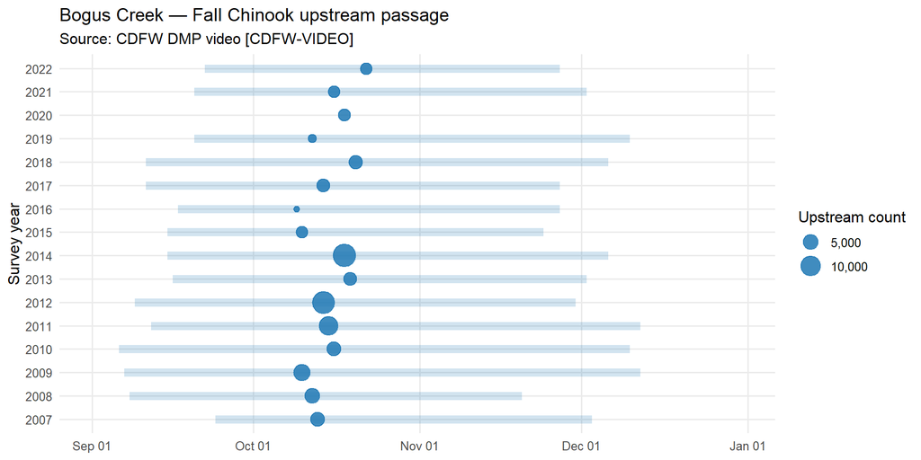

Bogus Creek fall Chinook run timing. Dot = peak week (size = annual count). Bar = full run window. Source: [CDFW-VIDEO].

## Coho — run timing

Bogus Creek coho upstream passage. Source: [CDFW-VIDEO]. Note: Dodrill et al. (2022) does not identify Bogus Creek as a coho natal tributary — coho observed here may be passing through.

| Year | Upstream count | First fish | Peak week | Last fish |
| --- | --- | --- | --- | --- |
| 2007 | 167 | Oct 25 | Nov 18 | Dec 04 |
| 2008 | 137 | Oct 17 | Nov 23 | Dec 22 |
| 2010 | 160 | Oct 25 | Dec 05 | Dec 13 |
| 2011 | 140 | Nov 01 | Nov 20 | Dec 10 |
| 2012 | 81 | Oct 26 | Nov 25 | Dec 06 |
| 2013 | 479 | Oct 25 | Nov 24 | Feb 02 |
| 2014 | 82 | Oct 26 | Nov 02 | Dec 07 |
| 2015 | 26 | Dec 02 | Dec 13 | Jan 13 |
| 2016 | 138 | Nov 07 | Nov 13 | Jan 01 |
| 2017 | 80 | Nov 10 | Dec 31 | Jan 23 |
| 2018 | 97 | Nov 16 | Dec 02 | Jan 11 |
| 2019 | 97 | Oct 23 | Dec 08 | Jan 25 |
| 2020 | 213 | Nov 13 | Nov 15 | Jan 27 |
| 2021 | 478 | Oct 28 | Nov 28 | Jan 16 |
| 2022 | 291 | Nov 01 | Nov 27 | Feb 03 |

## Steelhead — run timing

Bogus Creek steelhead upstream passage. Source: [CDFW-VIDEO].

| Year | Upstream count | First fish | Peak week | Last fish |
| --- | --- | --- | --- | --- |
| 2007 | 27 | Sep 19 | Nov 11 | Dec 04 |
| 2008 | 67 | Sep 14 | Sep 28 | Dec 22 |
| 2009 | 71 | Sep 03 | Oct 11 | Dec 13 |
| 2010 | 47 | Sep 18 | Oct 17 | Dec 13 |
| 2011 | 88 | Sep 18 | Oct 09 | Nov 28 |
| 2012 | 82 | Sep 13 | Nov 25 | Dec 05 |
| 2013 | 191 | Nov 19 | Mar 23 | Apr 30 |
| 2014 | 95 | Sep 25 | Sep 21 | Nov 29 |
| 2015 | 179 | Sep 27 | Oct 04 | Jan 13 |
| 2016 | 234 | Oct 09 | Mar 12 | Apr 29 |
| 2017 | 394 | Sep 14 | Feb 25 | May 11 |
| 2018 | 547 | Sep 10 | Mar 03 | May 08 |
| 2019 | 1,565 | Sep 28 | Mar 08 | May 04 |
| 2020 | 1,121 | Sep 29 | Feb 07 | May 09 |
| 2021 | 1,547 | Sep 19 | Feb 27 | May 01 |
| 2022 | 149 | Sep 25 | Jan 29 | Feb 04 |

# Shasta River

**River km:** 289.6 | **State:** CA | **Monitoring:** CDFW Region 1

The Shasta River confluence at rkm 289.6 marks the **upstream boundary of the *Ceratonova shasta* infectious zone** (rkm 289.6–213.0; Perry et al. 2019, p. 27). It is one of two primary coho natal tributaries in Dodrill et al. (2022).

## Fall Chinook — run timing

| Year | Upstream count | First fish | Peak week | Last fish |
| --- | --- | --- | --- | --- |
| 2006 | 2,310 | Sep 14 | Oct 01 | Dec 01 |
| 2007 | 2,106 | Sep 17 | Sep 30 | Dec 08 |
| 2008 | 6,697 | Sep 04 | Sep 28 | Dec 02 |
| 2009 | 7,667 | Sep 05 | Sep 27 | Dec 21 |
| 2010 | 1,356 | Sep 05 | Sep 19 | Dec 06 |
| 2011 | 11,588 | Sep 09 | Sep 25 | Jan 06 |
| 2012 | 28,881 | Sep 02 | Sep 23 | Nov 28 |
| 2013 | 8,052 | Sep 09 | Sep 29 | Dec 03 |
| 2014 | 18,155 | Sep 06 | Sep 21 | Dec 09 |
| 2015 | 6,588 | Sep 08 | Sep 27 | Dec 15 |
| 2016 | 2,889 | Sep 07 | Sep 25 | Dec 04 |
| 2017 | 9,618 | Sep 06 | Sep 24 | Dec 05 |
| 2018 | 20,309 | Sep 04 | Sep 30 | Jan 06 |
| 2019 | 5,924 | Sep 05 | Oct 06 | Jan 06 |
| 2020 | 4,253 | Sep 09 | Sep 27 | Dec 09 |
| 2021 | 6,970 | Sep 03 | Sep 26 | Nov 26 |
| 2022 | 4,176 | Sep 08 | Oct 02 | Dec 12 |

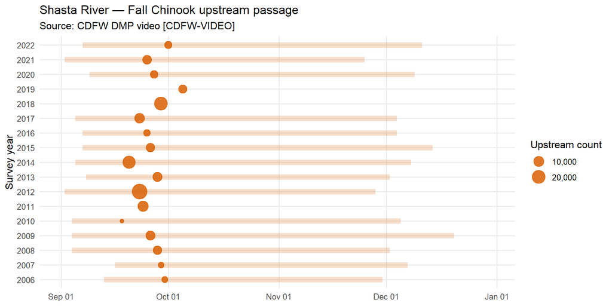

Shasta River fall Chinook run timing. Source: [CDFW-VIDEO].

## Coho — adult returns and run timing

Adult return estimates are **exact values from Table 2, Dodrill et al. (2022), p. 6**, citing CDFW. Peak immigration timing **mid-November to early December** with less inter-annual variation than Scott River (Dodrill et al. 2022, Fig. 5B).

Shasta River adult coho returns. Source: Table 2, Dodrill et al. (2022) [DODRILL-2022], p. 6.

| Brood year | Adult coho returns | Notes |
| --- | --- | --- |
| 2005 | 69 |  |
| 2006 | 47 |  |
| 2007 | 249 | Highest |
| 2008 | 30 |  |
| 2009 | 9 | Critically low |
| 2010 | 44 |  |
| 2011 | 62 |  |
| 2012 | 114 |  |
| 2013 | 163 |  |

| Year | Upstream count | First fish | Peak week | Last fish |
| --- | --- | --- | --- | --- |
| 2006 | 75 | Oct 13 | Oct 29 | Dec 03 |
| 2007 | 377 | Oct 19 | Nov 11 | Dec 12 |
| 2008 | 137 | Nov 07 | Nov 23 | Dec 22 |
| 2009 | 22 | Nov 02 | Nov 01 | Dec 18 |
| 2010 | 52 | Oct 26 | Nov 28 | Dec 16 |
| 2011 | 63 | Oct 18 | Nov 20 | Dec 31 |
| 2012 | 82 | Oct 10 | Nov 18 | Nov 29 |
| 2013 | 146 | Oct 19 | Nov 17 | Dec 08 |
| 2014 | 35 | Oct 10 | Nov 16 | Dec 08 |
| 2015 | 42 | Nov 19 | Dec 06 | Dec 19 |
| 2016 | 50 | Nov 09 | Nov 06 | Dec 13 |
| 2017 | 39 | Oct 29 | Nov 19 | Jan 09 |
| 2018 | 38 | Nov 07 | Nov 25 | Dec 27 |
| 2019 | 51 | Oct 23 | Dec 08 | Jan 02 |
| 2020 | 41 | Nov 14 | Nov 15 | Jan 06 |
| 2021 | 65 | Oct 28 | Dec 05 | Jan 02 |
| 2022 | 54 | Oct 28 | Dec 25 | Dec 28 |

## Steelhead — run timing

Shasta River steelhead upstream passage. Source: [CDFW-VIDEO].

| Year | Upstream count | First fish | Peak week | Last fish |
| --- | --- | --- | --- | --- |
| 2006 | 28 | Sep 14 | Sep 17 | Nov 28 |
| 2007 | 32 | Sep 16 | Oct 14 | Dec 06 |
| 2008 | 253 | Sep 10 | Nov 09 | Dec 22 |
| 2009 | 167 | Sep 19 | Oct 18 | Dec 27 |
| 2010 | 142 | Sep 25 | Oct 03 | Dec 16 |
| 2011 | 201 | Sep 02 | Dec 25 | Jan 06 |
| 2012 | 212 | Sep 23 | Oct 14 | Nov 30 |
| 2013 | 70 | Sep 18 | Sep 29 | Dec 08 |
| 2014 | 286 | Sep 14 | Oct 12 | Dec 10 |
| 2015 | 83 | Sep 13 | Sep 27 | Dec 10 |
| 2016 | 37 | Sep 16 | Nov 06 | Dec 10 |
| 2017 | 274 | Sep 07 | Oct 01 | Jan 10 |
| 2018 | 413 | Sep 08 | Sep 30 | Jan 07 |
| 2019 | 319 | Sep 08 | Sep 22 | Jan 08 |
| 2020 | 261 | Sep 08 | Dec 13 | Jan 10 |
| 2021 | 98 | Sep 11 | Oct 17 | Dec 31 |
| 2022 | 85 | Sep 20 | Dec 25 | Dec 30 |

# Scott River

**River km:** 232.8 | **State:** CA | **Monitoring:** SRWC; CDFW Region 1

The Scott River is excluded from Perry et al. (2019) calibration — it enters below the Kinsman trap (Perry et al. 2019, p. 23). It is one of two primary coho natal tributaries in Dodrill et al. (2022).

## Fall Chinook — run timing

Scott River fall Chinook upstream passage. Source: [CDFW-VIDEO]. Peak passage mid-to-late October. Low-count years (2015: 406; 2016: 395; 2018: 283; 2022: 70) indicate poor run years.

| Year | Upstream count | First fish | Peak week | Last fish |
| --- | --- | --- | --- | --- |
| 2008 | 3,267 | Oct 06 | Nov 02 | Nov 27 |
| 2009 | 1,204 | Oct 14 | Oct 18 | Dec 22 |
| 2010 | 1,965 | Sep 30 | Oct 24 | Dec 01 |
| 2011 | 3,838 | Sep 25 | Oct 09 | Dec 05 |
| 2012 | 6,707 | Oct 05 | Oct 14 | Nov 26 |
| 2013 | 2,845 | Oct 01 | Oct 20 | Nov 30 |
| 2014 | 7,902 | Oct 02 | Oct 19 | Dec 05 |
| 2015 | 406 | Oct 06 | Oct 18 | Dec 09 |
| 2016 | 395 | Oct 06 | Oct 09 | Nov 28 |
| 2017 | 2,172 | Sep 26 | Oct 22 | Nov 18 |
| 2018 | 283 | Oct 14 | Oct 28 | Dec 13 |
| 2019 | 1,366 | Sep 26 | Oct 13 | Dec 12 |
| 2020 | 257 | Sep 29 | Nov 15 | Dec 16 |
| 2021 | 718 | Oct 13 | Oct 17 | Nov 17 |
| 2022 | 70 | Oct 15 | Oct 23 | Dec 07 |

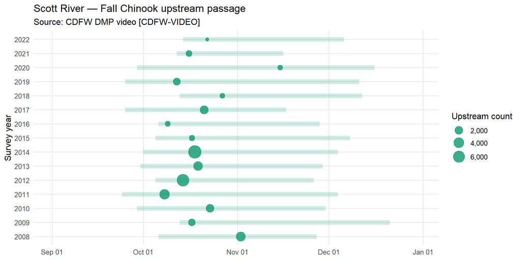

Scott River fall Chinook run timing. Source: [CDFW-VIDEO].

## Coho — adult returns and run timing

Adult return estimates from **Table 2, Dodrill et al. (2022), p. 6**. Peak immigration timing showed **considerable inter-annual variation, ranging from mid-October to late December** (Dodrill et al. 2022, Fig. 5A).

Scott River adult coho returns. Source: Table 2, Dodrill et al. (2022) [DODRILL-2022], p. 6.

| Brood year | Adult coho returns | Notes |
| --- | --- | --- |
| 2007 | 1622 | High year |
| 2008 | 63 | Very low |
| 2009 | 81 | Very low |
| 2010 | 927 |  |
| 2011 | 355 |  |
| 2012 | 201 |  |
| 2013 | 2752 | Highest in series |

| Year | Upstream count | First fish | Peak week | Last fish |
| --- | --- | --- | --- | --- |
| 2008 | 62 | Nov 02 | Nov 09 | Dec 27 |
| 2009 | 81 | Nov 20 | Dec 13 | Jan 01 |
| 2010 | 867 | Oct 26 | Oct 24 | Dec 10 |
| 2011 | 334 | Oct 19 | Nov 20 | Dec 30 |
| 2012 | 166 | Oct 27 | Nov 18 | Nov 29 |
| 2013 | 1,841 | Oct 21 | Nov 17 | Jan 05 |
| 2014 | 349 | Oct 23 | Nov 16 | Dec 06 |
| 2015 | 201 | Dec 04 | Dec 06 | Dec 09 |
| 2016 | 109 | Oct 22 | Nov 13 | Dec 08 |
| 2017 | 364 | Oct 24 | Nov 05 | Jan 04 |
| 2018 | 603 | Nov 23 | Nov 25 | Dec 18 |
| 2019 | 305 | Oct 23 | Dec 08 | Jan 04 |
| 2020 | 1,670 | Nov 16 | Nov 15 | Jan 04 |
| 2021 | 690 | Oct 24 | Dec 19 | Jan 02 |
| 2022 | 234 | Dec 07 | Dec 25 | Dec 26 |

## Scott River — Coho Salmon Spawning

**Source:** Scott River Watershed Council annual spawning ground surveys `[SRWC-2024]`, `[SRWC-2025]`. Coho only. Survey method: walk surveys, redd counting. A redd = nest excavated by a female, confirming spawning at that location.

### Season summary

| Season | Survey period | Miles surveyed | Total redds | Spawner estimate |
| --- | --- | --- | --- | --- |
| 2022-2023 | Jan 4–27, 2023 | 1.45 (4 reaches only) | 5 | 236 (CDFW weir) |
| 2023-2024 | Nov 28, 2023–Jan 16, 2024 | 38.3 | 251 | 912 (preliminary) |
| 2024-2025 | Nov 25, 2024–Jan 16, 2025 | 28.7 | 111 | 1,052 (preliminary) |

> 2022-2023 is an acknowledged undercount — high flows pushed fish into unsurveyed areas. Do not use for trend comparisons.

### Where spawning occurs

Table 25. Coho redd counts by reach, 2023-2024. Source: SRWC [SRWC-2024]

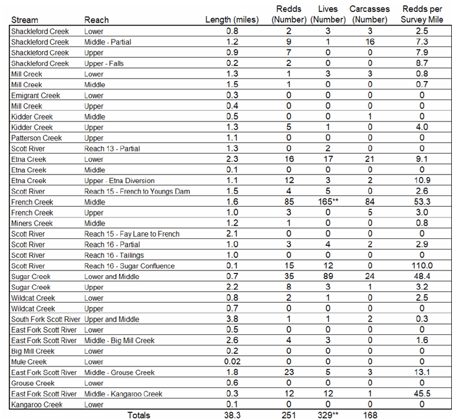

Table 3. Coho redd counts by reach, 2024-2025. Source: SRWC [SRWC-2025].

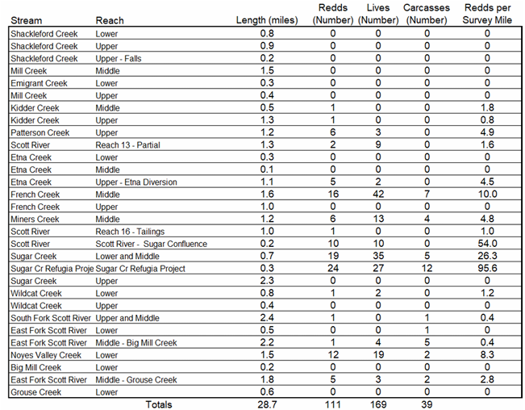

### How spatial distribution has shifted

Table 26. Redd distribution comparison 2020-2021 vs 2023-2024. Source: SRWC [SRWC-2024].

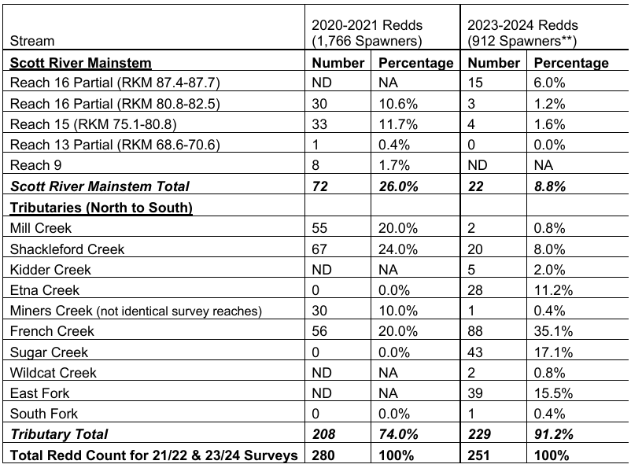

### When spawning occurs

| Season | First redds | Peak spawning | Last live fish |
| --- | --- | --- | --- |
| 2023-2024 | Nov 28, 2023 (Scott R. near Sugar Ck) | Mid-Dec to early Jan | Jan 16, 2024 |
| 2024-2025 | Nov 25, 2024 (French Ck, Sugar Ck) | Mid-Dec | Jan 16, 2025 |

## Steelhead — run timing

Scott River steelhead upstream passage. Source: [CDFW-VIDEO].

| Year | Upstream count | First fish | Peak week | Last fish |
| --- | --- | --- | --- | --- |
| 2008 | 147 | Oct 15 | Nov 02 | Dec 21 |
| 2009 | 199 | Oct 17 | Jan 03 | Jan 11 |
| 2010 | 421 | Oct 16 | Oct 31 | Jan 06 |
| 2011 | 253 | Sep 24 | Oct 09 | Jan 07 |
| 2012 | 149 | Oct 14 | Nov 18 | Nov 29 |
| 2013 | 56 | Oct 02 | Nov 17 | Dec 22 |
| 2014 | 742 | Oct 17 | Nov 30 | Dec 06 |
| 2016 | 88 | Oct 19 | Oct 16 | Dec 05 |
| 2017 | 70 | Oct 20 | Nov 12 | Jan 08 |
| 2018 | 210 | Oct 16 | Nov 25 | Dec 18 |
| 2019 | 252 | Oct 03 | Dec 08 | Jan 12 |
| 2020 | 213 | Nov 16 | Dec 20 | Jan 04 |
| 2021 | 67 | Oct 23 | Oct 24 | Jan 02 |
| 2022 | 22 | Nov 06 | Dec 25 | Dec 26 |

# Mainstem Klamath River — Fall Chinook

**Source: Perry et al. (2019) [PERRY-2019]**

Spawning confined to rkm 178–312. Most redds concentrated immediately below Iron Gate Dam (Perry et al. 2019, p. 36).

## Female spawner counts and timing

Exact values from **Table 6, p. 37**, citing Gough & Som (2015). Covers rkm 236–312 (Iron Gate Dam to Kinsman trap).

Female fall Chinook spawners in mainstem Klamath River (rkm 236–312). Peak spawning (50th percentile) consistently Oct 19–Nov 8. Source: Table 6, Perry et al. (2019) [PERRY-2019], p. 37. Series ends at brood year 2012.

| Brood year | 20th percentile | 50th percentile (peak) | 80th percentile | Female spawners |
| --- | --- | --- | --- | --- |
| 2004 | Oct 16 | Oct 24 | Oct 31 | 2,948 |
| 2006 | Oct 12 | Oct 19 | Oct 26 | 2,196 |
| 2007 | Nov 1 | Nov 8 | Nov 16 | 4,522 |
| 2008 | Oct 22 | Oct 29 | Nov 6 | 3,324 |
| 2009 | Oct 23 | Oct 31 | Nov 8 | 4,543 |
| 2010 | Oct 25 | Nov 1 | Nov 7 | 1,925 |
| 2011 | Oct 23 | Nov 1 | Nov 9 | 2,158 |
| 2012 | Oct 16 | Oct 24 | Oct 31 | 10,697 |

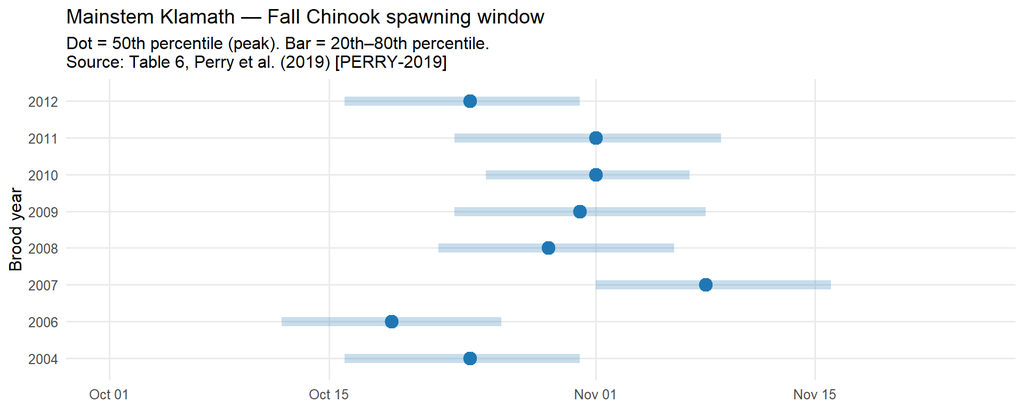

Mainstem fall Chinook peak spawning window by brood year. Dot = 50th percentile. Bar = 20th–80th percentile. Source: Table 6, Perry et al. (2019).

# Cross-Tributary Comparison

All figures in this section derived from `[CDFW-VIDEO]`.

## Fall Chinook — peak week by tributary

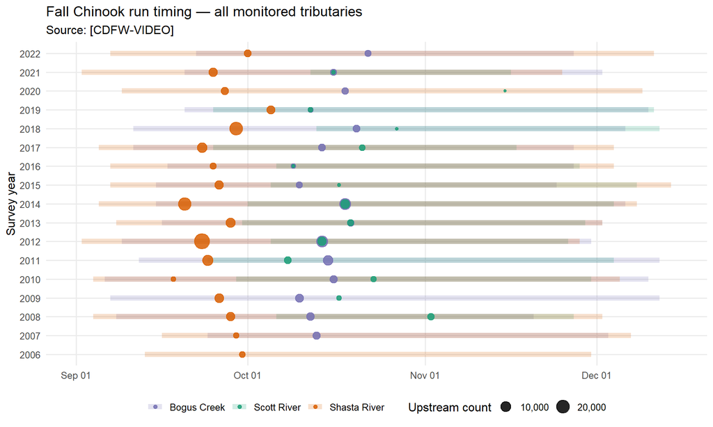

Fall Chinook peak upstream passage week by tributary and year. Dot = peak week (size = annual count). Bar = full run window. Years with fewer than 100 upstream fish excluded. Source: [CDFW-VIDEO].

## Fall Chinook — timing summary table

Fall Chinook run timing summary by tributary. Years with fewer than 100 upstream fish excluded. Dates are median day-of-year across all included years. Source: [CDFW-VIDEO].

| Tributary | Years of data | Median first fish | Median peak week | Median last fish | Median annual count |
| --- | --- | --- | --- | --- | --- |
| Bogus Creek | 16 | Sep 15 | Oct 14 | Dec 02 | 3,891 |
| Scott River | 14 | Oct 03 | Oct 17 | Dec 02 | 1,665 |
| Shasta River | 17 | Sep 05 | Sep 26 | Dec 04 | 6,697 |

## Coho — peak week by tributary

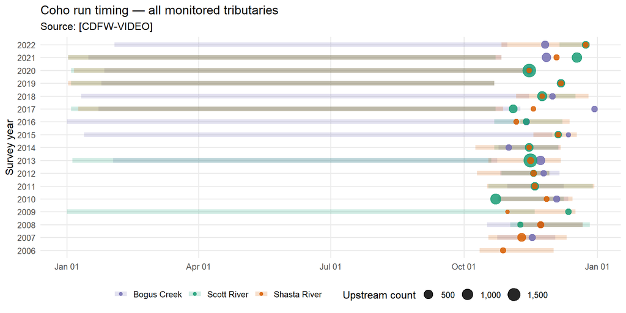

Coho peak upstream passage week by tributary and year. Source: [CDFW-VIDEO].

## Annual upstream counts — all species and tributaries

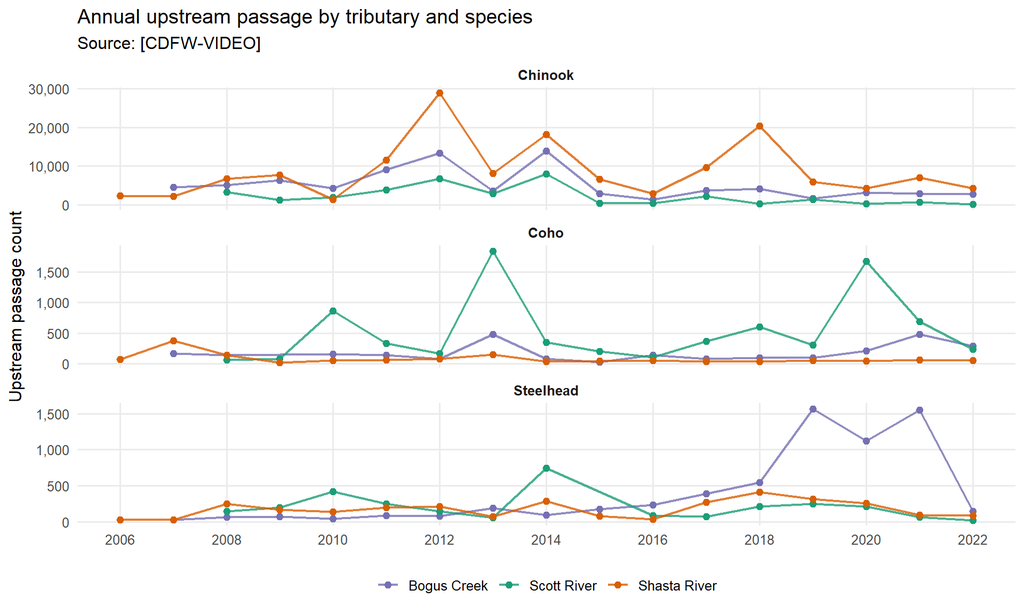

Annual upstream passage counts by tributary and species. Source: [CDFW-VIDEO].

# Sources Appendix

[output not shown]